# Assignment 14: Writing a function - Loop

*How to do it?*:

- Open the Rmarkdown file of this assignment (link) in Rstudio.
- Right under each **question**, insert a code chunk (you can use the hotkey `Ctrl + Alt + I` to add a code chunk) and code the solution for the question.
- `Knit` the rmarkdown file (hotkey: `Ctrl + Alt + K`) to export an html.
- Publish the html file to your Githiub Page.

*Submission*: Submit the link on Github of the assignment to Blackboard.

1. Write the following function. Give examples to test your function.
- Input: a data frame
- Output: a data frame with all the missing of numeric variables replaced by the associated means.

Hint: [Similar function](https://bryantstats.github.io/math421/gganimate/14_writing_functions.html#28)

```r
mean_impute <- function(data)
{
  for (i in 1:length(data))
  {
    if(is.numeric(data[[i]]))
    {
      data[[i]] <- mean(data[[i]],na.rm=TRUE)
    }

  }
  return(data)
  }
```

```r
library(tidyverse)
df<- read_csv('titanic.csv')
colSums(is.na(df))
```

```
## PassengerId    Survived      Pclass        Name         Sex         Age
##           0           0           0           0           0         177
##       SibSp       Parch      Ticket        Fare       Cabin    Embarked
##           0           0           0           0         687           2
```

2. Write the following function. Give examples to test your function.
- Input: a data frame
- Output: a data frame with all the missing of variables replaced by the associated means (for numeric variables) or modes (for non-numeric variables).

Hint: Combine the function in Problem 1 and the function in [this example](https://bryantstats.github.io/math421/gganimate/14_writing_functions.html#28)

```r
numeric_impute <- function(data)
{
  for (i in 1:length(data))
  {
    if(is.numeric(data[[i]]))
    {
      data[[i]]<-mean(data[[i]],na.rm=TRUE)
    }
    else
    {
      numeric_impute<-function(data)
      {
        for(i in 1:length(data))
        {
          data[[i]] <- mode_impute(data[[i]])
        }
        return(data)
      }
      }
    }
  }
```

```r
library(tidyverse)
df <- read_csv('titanic.csv')

x1<- mean_impute(df$Embarked)
sum(is.na(x1))
```

```
## [1] 2
```

3. Write the following function. Give examples to test your function.
- Input: a data frame
- Output: Bar plots of all non-numeric variables

Hint: [Similar function](https://bryantstats.github.io/math421/gganimate/14_writing_functions.html#32)

```r
bar_plot <- function(data)
{
  library(ggplot2)
  for (i in 1:length(data))
  {
    if (is.numeric(data[[i]]))
    {
      print(ggplot(data,aes(x = data[[1]]))+
      geom_bar(position = 'dodge')+
      labs(x = names(data)[1]))
    }
  }
}
```

```r
bar_plot(df)
```

[output not shown]

4. Write the following function. Give examples to test your function.
- Input: a data frame
- Output: all possible the bar plots of a non-numeric variable filled by a non-numeric variable.

Hint: [Similar function](https://bryantstats.github.io/math421/gganimate/14_writing_functions.html#40)

```r
bar_plot2 <- function(data)
{
  library(ggplot2)
  l <- length(data)
  for (i in 1:(l-1))
    for (j in (i+1):l)
  {
    if (is.numeric(data[[i]])& (!is.numeric(data[[j]])))
    {
      print(ggplot(data, aes(x = data[[i]], color = data[[j]]))+
              geom_bar()+labs(x = names(data)[i], color = names(data)[j]))
    }
  }
}
```

[figure not shown]

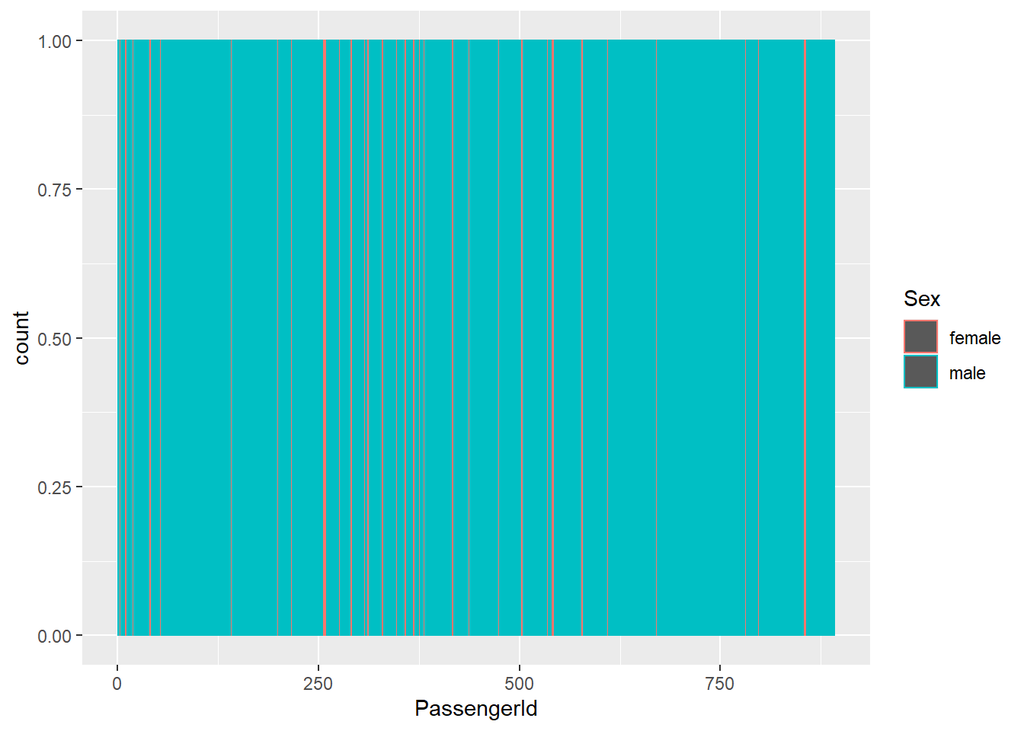

[figure not shown]

[figure not shown]

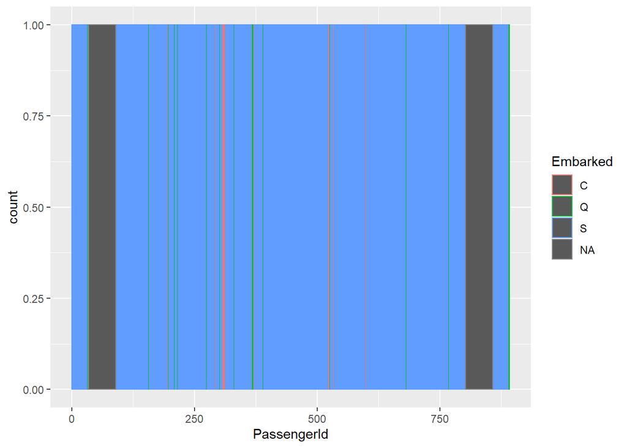

[figure not shown]

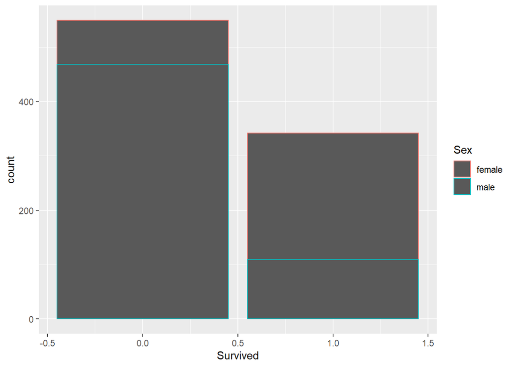

[figure not shown]

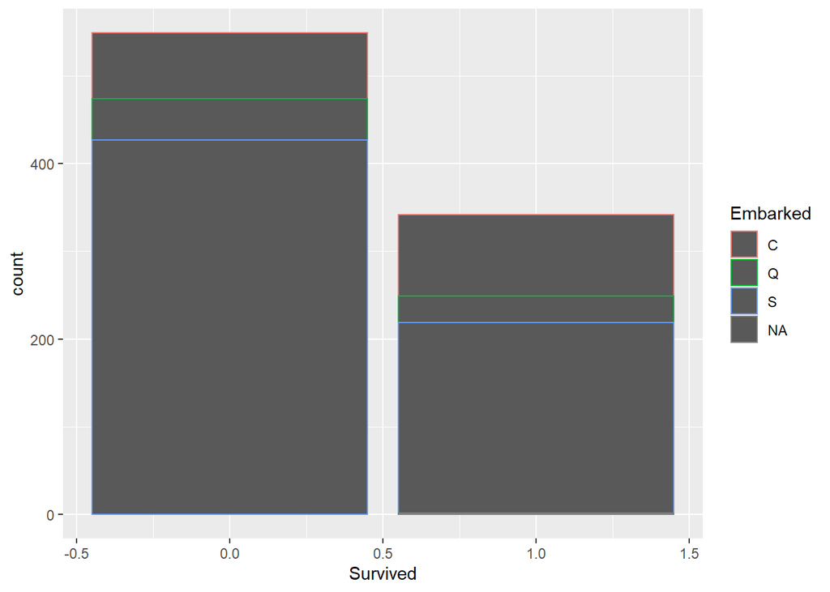

[figure not shown]

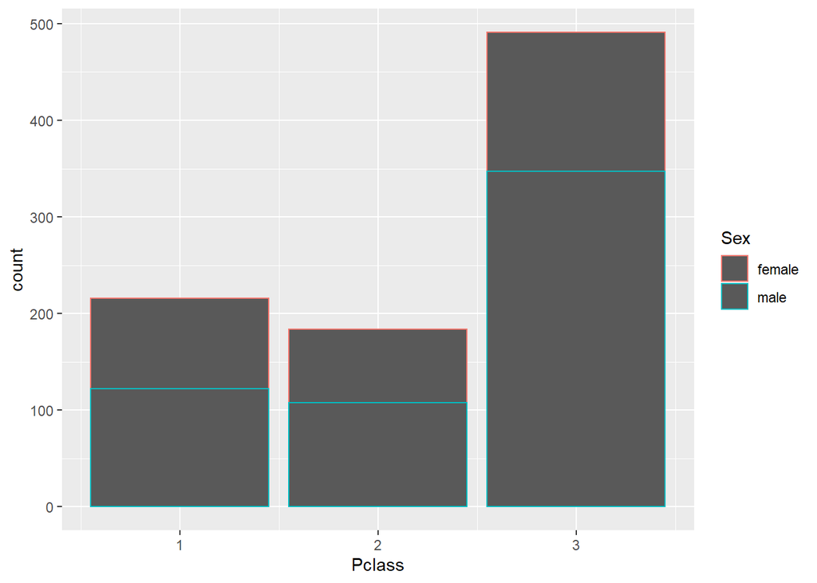

[figure not shown]

[10 more figures not shown]

```r
bar_plot2(df)
```

5. Write the following function. Give examples to test your function.
- Input: a data frame
- Output:
  - all possible the bar plots of a non-numeric variable filled by a non-numeric variable.
  - all possible the density plots of a numeric variable colored by a non-numeric variable
  - all possible the scatter plots.

Hint: Combine [this function](https://bryantstats.github.io/math421/gganimate/14_writing_functions.html#36), [this function](https://bryantstats.github.io/math421/gganimate/14_writing_functions.html#39), and the function in Question 4. One way to combine is creating a new function, `quick_plot`, and call these three functions within `quic_kplot`.

```r
quick_plot<- function(data)
{
  library(ggplot2)
  l <- length(data)
  for (i in 1:(l-1))
    for (j in (i+1):l)
  {
    if (is.numeric(data[[i]])& (!is.numeric(data[[j]])))
    {
      print(ggplot(data, aes(x = data[[i]], color = data[[j]]))+
              geom_bar()+labs(x = names(data)[i], color = names(data)[j]))
}

      return(data)
    }
  density_line <- function(data)
  {
     library(ggplot2)
  l <- length(data)
  for (i in 1:(l-1))
    for (j in (i+1):l)
  {
    if (is.numeric(data[[i]])& (!is.numeric(data[[j]])))
    {
      print(ggplot(data, aes(x = data[[i]], color = data[[j]]))+
              geom_density()+labs(x = names(data)[i], color = names(data)[j]))
  }
      return(data)
    }
    line_graph<-function(data)
   {
       library(ggplot2)
  l <- length(data)
  for (i in 1:(l-1))
    for (j in (i+1):l)
  {
    if (is.numeric(data[[i]])& (!is.numeric(data[[j]])))
    {
      print(ggplot(data, aes(x = data[[i]], color = data[[j]]))+
              geom_line()+labs(x = names(data)[i], color = names(data)[j]))
      }
      return(data)
    }
   }
  }
}
```

```r
#My code runs, but I'm not sure why it isn't printing out an output of the graphs.
```